# Route 1 simulation draft

SW gate, SW+L gate, and Welch default

## Route 1 decision problem

Abbreviations used throughout: `F` = Fisher’s ANOVA; `W` = Welch’s heteroscedastic ANOVA; `L` = Levene gate selecting F or W; `KW` = Kruskal–Wallis; `SW` = Shapiro–Wilk gate selecting W or KW; `SW+L` = Shapiro–Wilk gate selecting KW or, if the mean branch is retained, L.

Route 1 is the only branch in which `visstat()` lets assumption tests select the final test. The current code fits a group model, tests the standardised residuals, and uses the Shapiro–Wilk result as the first gate: rejected residual normality routes to Wilcoxon or Kruskal–Wallis; retained residual normality keeps the result in the mean-based branch. The design question is therefore specific: should the parametric side of the SW gate default directly to Welch (`SW`), or should it include the Levene gate (`SW+L`) and select Fisher/Student only when homoscedasticity is not rejected?

Rochon et al. (Rochon et al. 2012) is used only as background here: two-stage testing can change conditional error rates, so the final procedure must be judged by its simulated final-test rejection rates.

The argument is read as figure-table pairs. Figure 1/Table 1 checks whether the candidate routes keep the nominal rejection rate when both the equal-means and rank-distribution nulls are true. Figure 2/Table 2 keeps the equal-means null true but violates equality of distributions, so F, W, and L remain mean-null tests while SW and SW+L become final-test rejection rates after possible hypothesis switching. Figure 3/Table 3 then asks the power question under real ordered group differences, and the final Fisher/Welch table isolates the parametric branch.

## Simulation design

The simulation layout follows the competitor logic. Blanca et al. (Blanca et al. 2017) assess Fisher’s ANOVA under zero group effect, non-normal distributions, balanced and unbalanced group sizes, and Bradley’s robustness criterion. Delacre et al. (Delacre et al. 2019) cross sample-size ratios, SD ratios, and sample-size/SD pairings to compare Fisher-type and Welch-type ANOVA. Fagerland and Sandvik (Fagerland and Sandvik 2009) separate the equal-means target from rank-based targets and show why rank tests must not be read as mean tests when distributional shapes differ. We therefore use two Type I settings: identical distributions, where both the equal-means and equal-rank-distribution nulls are true, and equal means with unequal distributions, where only the equal-means null is the common target for F, W, and L.

The normal input is the standard normal distribution, $X \sim \mathcal{N}(0,1)$: mean 0, variance 1, skewness 0, and kurtosis 3. Excess kurtosis is kurtosis minus 3, so it is 0 for the standard normal distribution. Gamma input follows the standardised Gamma path. For $X \sim \Gamma(\alpha,\theta)$, with shape parameter $\alpha>0$ and scale parameter $\theta>0$, the mean is $E(X)=\alpha\theta$, the variance is $\mathrm{Var}(X)=\alpha\theta^2$, the skewness is $2/\sqrt{\alpha}$, and the kurtosis is $3+6/\alpha$. The excess kurtosis, reported in the tables, is therefore $6/\alpha$ (Forbes et al. 2010, 109). In the simulations $\theta=1$, $\alpha\in\{16,4,1,0.25\}$, and the draws are standardised by $Z=(X-\alpha\theta)/(\theta\sqrt{\alpha})$. Thus the Gamma columns deliberately vary skewness and excess kurtosis together.

All simulation cells use $B=50{,}000$ Monte Carlo replications. For an estimated rejection probability $\hat p$, where $\hat p$ is the rejection rate shown in the corresponding cell, and for gates the rejection rate of the final selected test,
$$SE_{\mathrm{MC}}=\sqrt{\hat p(1-\hat p)/B}.$$
This is about 0.10% percentage points at $\hat p=0.05$. The maximum is 0.22% percentage points at $\hat p=0.50$.

## Identical distributions and identical means

Figure @ref(fig:route1-identical-typeI) is the clean null case. All groups have the same population mean and the same distribution; therefore the equal-means null is true for F, W, and L, and the rank-distribution null is also true for KW. This is the only Type I figure where standalone KW is a valid comparator.

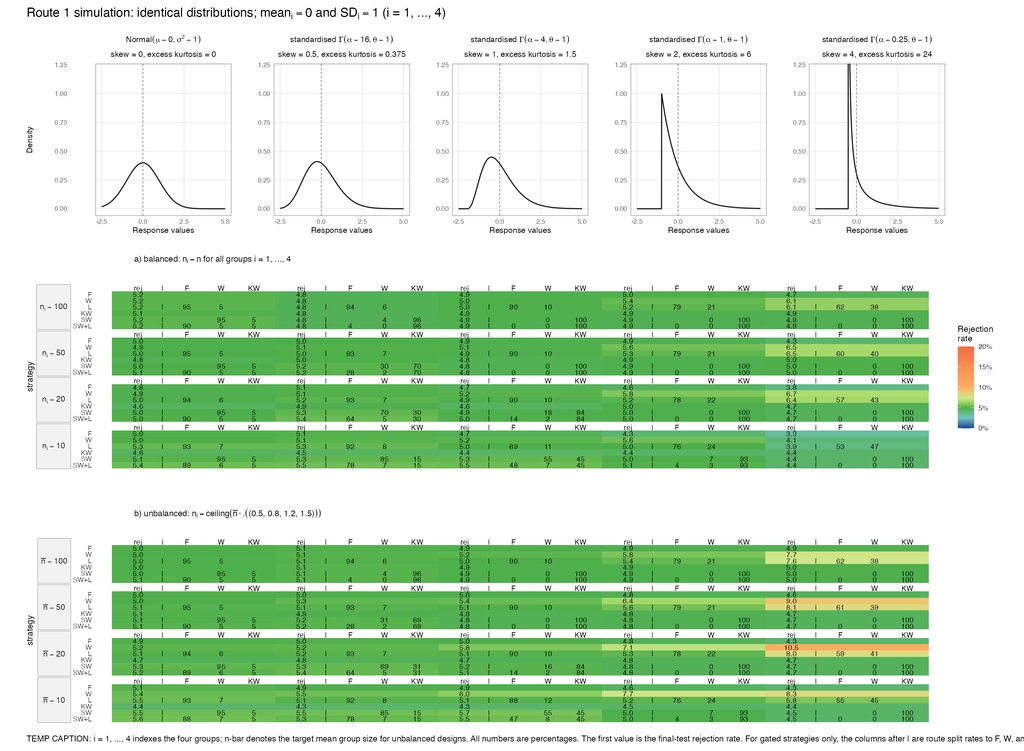

Route 1 Type I simulation under identical distributions and identical means. The heatmap reports final-test rejection rates at α = 5%. Green marks Bradley’s 2.5%–7.5% interval. Cells for SW and SW+L additionally report the route split.

Table @ref(tab:route1-identical-table) summarises the same figure by distribution shape. Across the identical-distribution cells, SW and SW+L remain inside Bradley’s interval. Their mean final-test rejection rates are 5.01% and 5.03%, respectively. The important point is not that SW fails to route to KW under skew; it does route to KW. The point is that this does not create false rejection here, because the rank-distribution null is true as well.

Figure 1 summary by distribution shape. Entries are ranges across the displayed n-regimes.

| Distribution | Skewness | Excess kurtosis | α-error / rejection rate of final test F | α-error / rejection rate of final test W | α-error / rejection rate of final test L | α-error / rejection rate of final test KW | α-error / rejection rate of final test SW | α-error / rejection rate of final test SW+L | Routing rate: test selected SW to W | Routing rate: test selected SW to KW | Routing rate: test selected SW+L to F | Routing rate: test selected SW+L to W | Routing rate: test selected SW+L to KW |
| --- | --- | --- | --- | --- | --- | --- | --- | --- | --- | --- | --- | --- | --- |
| normal, mean = 0, SD = 1 | 0 | 0 | 4.8–5.2% | 4.9–5.4% | 5.0–5.5% | 4.4–5.1% | 5.0–5.5% | 5.0–5.6% | 94.8–95.2% | 4.8–5.2% | 88.2–90.1% | 5.0–7.0% | 4.8–5.2% |
| standardised Gamma, α = 16 | 0.5 | 0.375 | 4.8–5.1% | 4.8–5.5% | 4.8–5.3% | 4.3–5.1% | 4.8–5.5% | 4.8–5.5% | 4.3–85.0% | 15.0–95.7% | 4.0–78.0% | 0.3–7.2% | 15.0–95.7% |
| standardised Gamma, α = 4 | 1 | 1.5 | 4.7–5.0% | 5.0–6.0% | 4.9–5.1% | 4.3–4.9% | 4.8–5.7% | 4.8–5.5% | 0.0–55.0% | 45.0–100.0% | 0.0–47.6% | 0.0–7.7% | 45.0–100.0% |
| standardised Gamma, α = 1 | 2 | 6 | 4.3–5.0% | 5.4–7.7% | 5.0–5.6% | 4.4–5.0% | 4.8–5.0% | 4.8–5.1% | 0.0–7.4% | 92.6–100.0% | 0.0–4.1% | 0.0–3.4% | 92.6–100.0% |
| standardised Gamma, α = 0.25 | 4 | 24 | 3.3–4.9% | 4.1–10.5% | 3.9–8.1% | 4.4–5.0% | 4.4–5.0% | 4.4–5.0% | 0.0–0.0% | 100.0–100.0% | 0.0–0.0% | 0.0–0.0% | 100.0–100.0% |

## Equal means but unequal distributions

Figure @ref(fig:route1-unequal-typeI) is the mean-null stress test. The group means are equal, but the group distributions differ through the SD design. Therefore F, W, and L still assess the equal-means null, but KW is not a standalone Type I comparator for that null. SW and SW+L are retained in the figure because they are the actual automatic procedures; their cells report the rejection rate of the final selected test after a possible switch to KW.

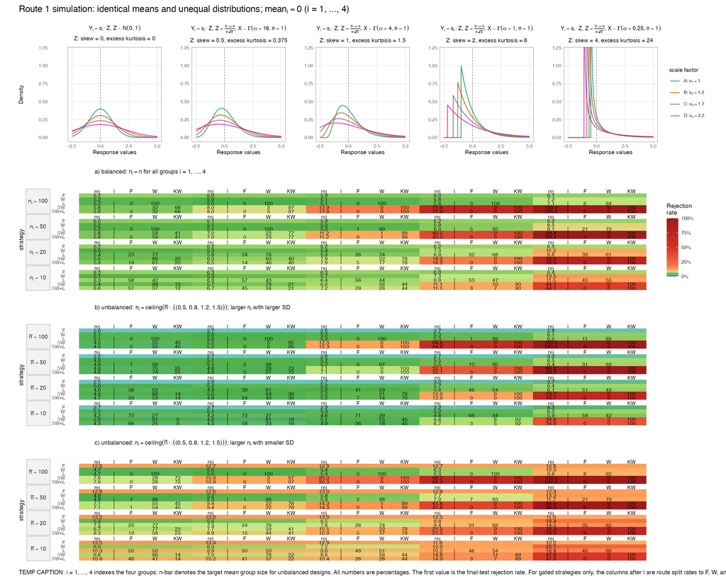

The upper panels show the theoretical response distributions used in the simulation. In each column, the base variable $Z$ is either standard normal (first column) or standardised Gamma (remaining columns). The plotted population PDFs correspond to $Y_i = s_i Z$, with scale factors $s_1 = 1.0$, $s_2 = 1.3$, $s_3 = 1.7$, and $s_4 = 2.2$ for groups A–D, respectively. The skewness and excess kurtosis printed above each panel refer to the base variable $Z$. The three heatmap blocks use the same four response distributions but different sample-size pairings: balanced $n_i=n$, unbalanced $n_i$ increasing with $s_i$, and unbalanced $n_i$ decreasing with $s_i$. F, W, and L test the equal-means null. SW and SW+L report final-test rejection after possible routing to KW. Standalone KW is omitted because its rank-distribution null is not the ground truth in these rows.

Figure 2 summary by distribution shape. Entries are ranges across the unequal-distribution n/SD regimes.

| Distribution | Skewness | Excess kurtosis | Mean-null rejection rate for F/W/L; final-test rejection for SW/SW+L F | Mean-null rejection rate for F/W/L; final-test rejection for SW/SW+L W | Mean-null rejection rate for F/W/L; final-test rejection for SW/SW+L L | Mean-null rejection rate for F/W/L; final-test rejection for SW/SW+L SW | Mean-null rejection rate for F/W/L; final-test rejection for SW/SW+L SW+L | Routing rate: test selected SW to W | Routing rate: test selected SW to KW | Routing rate: test selected SW+L to F | Routing rate: test selected SW+L to W | Routing rate: test selected SW+L to KW |
| --- | --- | --- | --- | --- | --- | --- | --- | --- | --- | --- | --- | --- |
| normal, mean = 0, SD = 1 | 0 | 0 | 2.5–13.5% | 4.7–6.0% | 4.2–10.3% | 4.5–7.6% | 4.3–10.6% | 27.6–90.5% | 9.5–72.4% | 0.0–65.8% | 24.8–73.9% | 9.5–72.4% |
| standardised Gamma, α = 16 | 0.5 | 0.375 | 2.6–13.4% | 5.0–6.3% | 4.2–9.9% | 4.8–10.9% | 4.3–10.9% | 3.1–81.0% | 19.0–96.9% | 0.0–57.6% | 3.1–46.2% | 19.0–96.9% |
| standardised Gamma, α = 4 | 1 | 1.5 | 2.5–13.0% | 5.1–7.2% | 4.6–9.6% | 5.1–20.3% | 4.9–20.3% | 0.0–56.1% | 43.9–100.0% | 0.0–36.1% | 0.0–28.1% | 43.9–100.0% |
| standardised Gamma, α = 1 | 2 | 6 | 2.7–12.8% | 5.2–12.0% | 4.8–10.2% | 6.6–71.9% | 6.7–71.9% | 0.0–10.6% | 89.4–100.0% | 0.0–3.3% | 0.0–7.2% | 89.4–100.0% |
| standardised Gamma, α = 0.25 | 4 | 24 | 2.8–12.6% | 6.1–25.1% | 5.9–16.8% | 34.8–100.0% | 34.8–100.0% | 0.0–0.1% | 99.9–100.0% | 0.0–0.0% | 0.0–0.1% | 99.9–100.0% |

## Power under ordered group differences

Figure @ref(fig:route1-power) addresses the complementary question: if real ordered group differences exist, how much power is lost or gained by SW and SW+L? This completed power simulation is balanced and homoscedastic, with four group means shifted by 0, 0.25, 0.50, and 0.75 SD. It is therefore a power simulation, not a Type I simulation, and it does not replace Figure @ref(fig:route1-unequal-typeI).

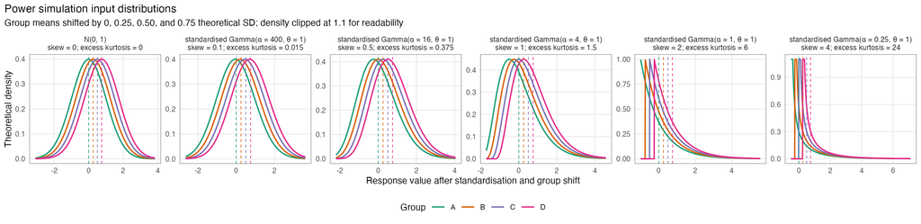

Theoretical input PDFs for the Route 1 power simulation. Groups A–D use the same standardised normal or Gamma shape, with additive mean shifts of 0, 0.25, 0.50, and 0.75 theoretical standard deviations. Dashed vertical lines mark the group means. The density scale is clipped at 1.1 for readability in the high-skew Gamma panel.

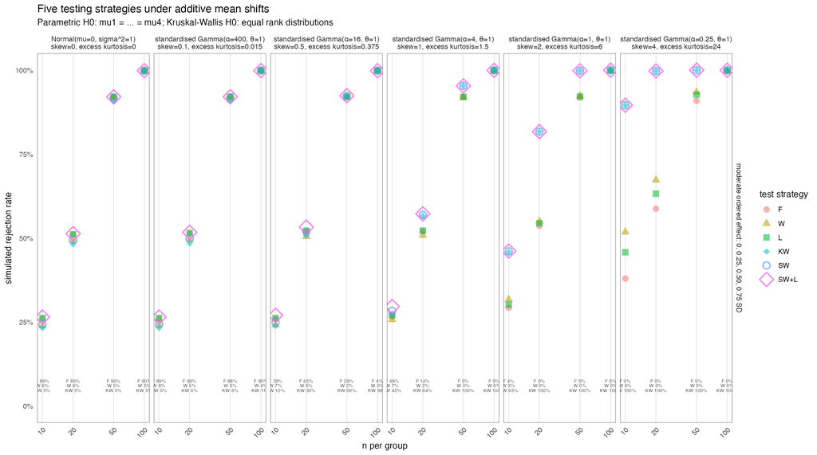

Power simulation for four balanced homoscedastic groups with ordered additive mean shifts of 0, 0.25, 0.50, and 0.75 SD. The y-axis is the probability that the final test rejects at α = 5%. The bottom annotations show the route probabilities for the SW+L gate.

Table @ref(tab:route1-power-table) summarises Figure @ref(fig:route1-power) by distribution shape; the figure keeps the n-specific detail. Around normality and mild Gamma skew, SW+L has slightly higher power than SW because the Levene gate sometimes retains Fisher in homoscedastic data. At stronger skew, both SW and SW+L route almost entirely to KW and their power is practically identical.

| Distribution | Skewness | Excess kurtosis | Power / rejection rate of final test F | Power / rejection rate of final test W | Power / rejection rate of final test L | Power / rejection rate of final test KW | Power / rejection rate of final test SW | Power / rejection rate of final test SW+L | Power / rejection rate of final test SW+L regret | Routing rate: test selected SW to W | Routing rate: test selected SW to KW | Routing rate: test selected SW+L to F | Routing rate: test selected SW+L to W | Routing rate: test selected SW+L to KW |
| --- | --- | --- | --- | --- | --- | --- | --- | --- | --- | --- | --- | --- | --- | --- |
| normal, mean = 0, SD = 1 | 0 | 0 | 73.8% | 73.0% | 73.9% | 72.4% | 73.1% | 73.9% | 0.01% | 94.9–95.2% | 4.8–5.1% | 88.7–90.1% | 4.8–6.5% | 4.8–5.1% |
| standardised Gamma, α = 400 | 0.1 | 0.015 | 73.9% | 73.1% | 73.9% | 72.5% | 73.2% | 74.0% | 0.01% | 83.8–94.8% | 5.2–16.2% | 79.4–88.8% | 4.4–6.2% | 5.2–16.2% |
| standardised Gamma, α = 16 | 0.5 | 0.375 | 74.0% | 73.3% | 74.1% | 73.3% | 73.8% | 74.5% | 0.00% | 0.0–84.7% | 15.3–100.0% | 0.0–77.8% | 0.0–6.9% | 15.3–100.0% |
| standardised Gamma, α = 4 | 1 | 1.5 | 74.1% | 73.6% | 74.2% | 75.9% | 76.1% | 76.4% | 0.00% | 0.0–55.1% | 44.9–100.0% | 0.0–47.7% | 0.0–7.4% | 44.9–100.0% |
| standardised Gamma, α = 1 | 2 | 6 | 74.9% | 75.8% | 75.3% | 85.5% | 85.5% | 85.5% | 0.00% | 0.0–7.4% | 92.6–100.0% | 0.0–4.1% | 0.0–3.3% | 92.6–100.0% |
| standardised Gamma, α = 0.25 | 4 | 24 | 77.4% | 82.5% | 80.3% | 97.9% | 97.9% | 97.9% | 0.00% | 0.0–0.0% | 100.0–100.0% | 0.0–0.0% | 0.0–0.0% | 100.0–100.0% |

## Fisher versus Welch inside the parametric branch

The power simulation behaves as expected in the balanced homoscedastic corner: F has the largest or equal power, W is slightly lower at small $n$, and the difference disappears as power saturates. The algebraic reference for this finite-$n$ difference is given in the package appendix, Eq. @ref(eq:welch-anova-four-groups):
$$\frac{F}{F_W}=1+\frac{3}{5(n-1)}.$$
Thus $F/F_W-1=3/[5(n-1)]$, so the statistic-level relative difference is $O(1/n)$. This is not a power-ratio identity; the observed rejection rates only show the expected ordering and its disappearance with increasing $n$. This small homoscedastic advantage is not an argument for variance pretesting. The literature consistently separates the two issues: Welch-type tests are recommended as unconditional mean tests when equal variances are doubtful (Welch 1951; Rasch et al. 2011; Delacre et al. 2019), whereas choosing Student/Fisher or Welch after a preliminary variance test is discouraged because the selection step changes the operating characteristics of the final test (Moser and Stevens 1992; Zimmerman 2004; Rochon et al. 2012).

The only remaining reason for `SW+L` is therefore not statistical optimality for the equal-means null, but consistency with the displayed model. Route 1 shows the residual diagnostics of the equal-variance Gaussian group model; if both displayed GLM assumptions pass, keeping Fisher/Student available makes the reported test correspond to the model just diagnosed. If that design link is not wanted, the literature and the present simulations both favour the simpler `SW` route: Shapiro–Wilk retained means Welch, Shapiro–Wilk rejected means KW.

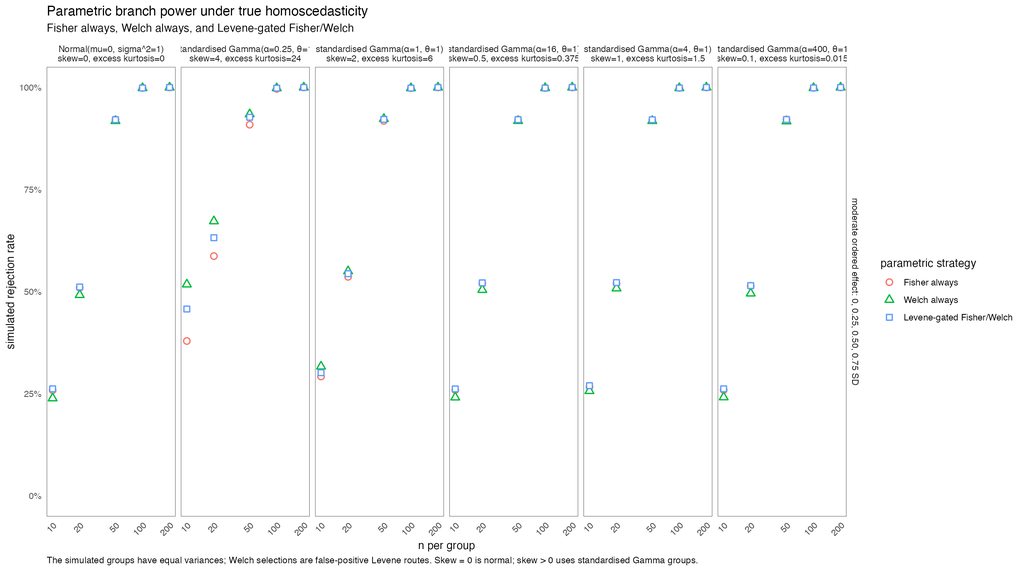

Fisher/Welch comparison in the normal homoscedastic corner of the power simulation.

| n | F/F_W theory | F power | W power | L power | SW+L to F | SW+L to W | SW+L to KW |
| --- | --- | --- | --- | --- | --- | --- | --- |
| 10 | 1.0667 | 25.9% | 23.9% | 26.2% | 88.7% | 6.5% | 4.8% |
| 20 | 1.0316 | 51.0% | 49.2% | 51.1% | 89.5% | 5.5% | 5.0% |
| 50 | 1.0122 | 92.1% | 91.8% | 92.1% | 90.1% | 5.0% | 4.9% |
| 100 | 1.0061 | 99.9% | 99.9% | 99.9% | 90.1% | 4.9% | 5.0% |
| 200 | 1.0030 | 100.0% | 100.0% | 100.0% | 90.1% | 4.8% | 5.1% |

## Interpretation for Route 1

Thus the simulations do not prove that SW+L is the best equal-means procedure. They show the price and benefit of the automatic route. The price is that, under equal means but unequal distributions, SW and SW+L often report the rejection rate of KW after the hypothesis has changed. The benefit is that the switch is visible and diagnostic-driven. The final design decision is therefore not statistical optimality in the abstract, but which default the package wants to make explicit: Welch for fixed equal-means inference, SW for a parsimonious shape-based switch, or SW+L for the same switch while preserving the GLM Fisher/Student branch when its displayed assumptions pass.

For later reference, the automatic Route 1 default is SW+L, not because it is the statistically optimal equal-means procedure, but because it is the only default consistent with the graphical contract of `visstat()`: the software shows residual normality and homoscedasticity diagnostics for the Gaussian equal-variance GLM, so if both displayed assumptions pass, the output may remain in the Fisher/Student branch. The literature still supports Welch as the safer unconditional mean-test default when the only goal is equal-means inference and variance pretesting is discouraged (Welch 1951; Rasch et al. 2011; Zimmerman 2004; Delacre et al. 2019), and this is visible in Figure @ref(fig:route1-unequal-typeI). The simulations show that SW+L behaves close to SW while preserving the Fisher/Student branch when both displayed assumptions pass (Figures @ref(fig:route1-identical-typeI)–@ref(fig:route1-power)). The honest interface is therefore: automatic = SW+L as a transparent assumption-based teaching/default route; parametric override = Welch for fixed equal-means inference; nonparametric override = Wilcoxon/Kruskal–Wallis when the user wants the rank-distribution comparison.

Blanca, María, Rafael Alarcón, Jaume Arnau, Roser Bono, and Rebecca Bendayan. 2017. “Non-Normal Data: Is ANOVA Still a Valid Option?” *Psicothema* 4 (29): 552–57. https://doi.org/10.7334/psicothema2016.383.

Delacre, Marie, Christophe Leys, Youri L. Mora, and Daniël Lakens. 2019. “Taking Parametric Assumptions Seriously: Arguments for the Use of Welch’s F-test Instead of the Classical F-test in One-Way ANOVA.” *International Review of Social Psychology* 32 (1). https://doi.org/10.5334/irsp.198.

Fagerland, Morten W., and Leiv Sandvik. 2009. “Performance of Five Two-Sample Location Tests for Skewed Distributions with Unequal Variances.” *Contemporary Clinical Trials* 30 (5): 490–96. https://doi.org/10.1016/j.cct.2009.06.007.

Forbes, Catherine, Merran Evans, Nicholas Hastings, and Brian Peacock. 2010. *Statistical Distributions*. 1st ed. Wiley. https://doi.org/10.1002/9780470627242.

Moser, B K, and G. R. Stevens. 1992. “Homogeneity of Variance in the Two-Sample Means Test.” *The American Statistician*, February, 19–21. https://doi.org/10.1080/00031305.1992.10475839.

Rasch, Dieter, Klaus D. Kubinger, and Karl Moder. 2011. “The Two-Sample t Test: Pre-Testing Its Assumptions Does Not Pay Off.” *Statistical Papers* 52 (1): 219–31. https://doi.org/10.1007/s00362-009-0224-x.

Rochon, Justine, Matthias Gondan, and Meinhard Kieser. 2012. “To Test or Not to Test: Preliminary Assessment of Normality When Comparing Two Independent Samples.” *BMC Medical Research Methodology* 12 (1): 81. https://doi.org/10.1186/1471-2288-12-81.

Welch, B. L. 1951. “On the Comparison of Several Mean Values: An Alternative Approach.” *Biometrika* 38 (3/4): 330–36. https://doi.org/10.2307/2332579.

Zimmerman, Donald W. 2004. “A Note on Preliminary Tests of Equality of Variances.” *British Journal of Mathematical and Statistical Psychology* 57 (1): 173–81. https://doi.org/10.1348/000711004849222.